# R - Assignment Mod 2 Week 3 - Pizza EDA

Michael Womble

1/28/2022

```r
# 1. Answer each question using in words/paragraph.
# 2. DO NOT use comments inside code blocks (like here) to answer anything. Those are for notes between coders/self. They
# will be ignored, and not counted as answers.
# 3. Keep the line/option    knitr::opts_chunk$set(warning = F, results = "hide", message = F)
# You can temporarily turn this on/off and use other option while you are working on the homework if it helps.
# The submitted work should have this option selected instead.
# 4. All charts/graphs/tables should have appropriate captions.
```

```r
#' Original outlierKD function by By Klodian Dhana,
#' https://www.r-bloggers.com/identify-describe-plot-and-remove-the-outliers-from-the-dataset/
#' Modified to have third argument for removing outliers instead of interactive prompt,
#' and after removing outlier, original df will not be changed. The function returns the a df,
#' which can be saved as original df name if desired.
#' Also added QQ-plot in the output, with options to show/hide boxplot, histogram, qqplot.
#' Check outliers, and option to remove them, save as a new dataframe.
#' @param df The dataframe.
#' @param var The variable in the dataframe to be checked for outliers
#' @param rm Boolean. Whether to remove outliers or not.
#' @param boxplt Boolean. Whether to show the boxplot, before and after outliers removed.
#' @param histogram Boolean. Whether to show the histogram, before and after outliers removed.
#' @param qqplt Boolean. Whether to show the qqplot, before and after outliers removed.
#' @return The dataframe with outliers replaced by NA if rm==TRUE, or df if nothing changed
#' @examples
#'   outlierKD2(mydf, height, FALSE, TRUE, TRUE, TRUE)
#'   mydf = outlierKD2(mydf, height, TRUE, TRUE, TRUE, TRUE)
#'   mydfnew = outlierKD2(mydf, height, TRUE)
#' @export
outlierKD2 <- function(df, var, rm=FALSE, boxplt=FALSE, histogram=TRUE, qqplt=FALSE,
                       with_col='Gray', without_col='Gray',
                       qqx=c(), qqy=c(), histx=c(), histy=c(), boxx=c(), boxy=c()) {
  dt = df # duplicate the dataframe for potential alteration
  var_name <- eval(substitute(var),eval(dt))
  na1 <- sum(is.na(var_name))
  m1 <- mean(var_name, na.rm = T)
  colTotal <- boxplt+histogram+qqplt
  with_color<-with_col
  without_color<-without_col
  par(mfrow=c(2, max(2,colTotal)), oma=c(0,0,3,0)) # fixed issue with only 0 or 1 chart selected
  if (qqplt) {
    qqnorm(var_name, main = "With outliers", col=with_color, ylim=qqy, xlim=qqx)
    qqline(var_name)
  }
  if (histogram) { hist(var_name, main="With outliers", xlab=NA, ylab=NA, col=with_color, xlim=histx, ylim=histy) }
  if (boxplt) { boxplot(var_name, main="With outliers", col=with_color, ylim=boxy, xlim=boxx) }

  outlier <- boxplot.stats(var_name)$out
  mo <- mean(outlier)
  var_name <- ifelse(var_name %in% outlier, NA, var_name)
  if (qqplt) {
    qqnorm(var_name, main = "Without outliers", col=without_color, xlim=qqx, ylim=qqy)
    qqline(var_name)
  }
  if (histogram) { hist(var_name, main="Without outliers", xlab=NA, ylab=NA, col=without_color, xlim=histx, ylim=histy) }
  if (boxplt) { boxplot(var_name, main="Without outliers", col=without_color, xlim=boxx, ylim=boxy) }

  if(colTotal > 0) {  # if no charts are wanted, skip this section
    title("Outlier Check", outer=TRUE)
    na2 <- sum(is.na(var_name))
    cat("Outliers identified:", na2 - na1, "\n")
    cat("Propotion (%) of outliers:", round((na2 - na1) / sum(!is.na(var_name))*100, 1), "\n")
    cat("Mean of the outliers:", round(mo, 2), "\n")
    m2 <- mean(var_name, na.rm = T)
    cat("Mean without removing outliers:", round(m1, 2), "\n")
    cat("Mean if we remove outliers:", round(m2, 2), "\n")
  }

  # response <- readline(prompt="Do you want to remove outliers and to replace with NA? [yes/no]: ")
  # if(response == "y" | response == "yes"){
  if(rm){
      dt[as.character(substitute(var))] <- invisible(var_name)
      #assign(as.character(as.list(match.call())$dt), dt, envir = .GlobalEnv)
      cat("Outliers successfully removed", "\n")
      return(invisible(dt))
  } else {
      cat("Nothing changed", "\n")
      return(invisible(df))
  }
}
```

# HW Assignment - EDA

This pizza ingredient dataset is from data.world (@sdhilip) The variables are:

| Variable | Definition |
| --- | --- |
| brand | Pizza brand |
| id | ID |
| mois | Amount of water per 100 grams in the sample |
| prot | Amount of protein per 100 grams in the sample |
| fat | Amount of fat per 100 grams in the sample |
| ash | Amount of ash per 100 grams in the sample |
| sodium | Amount of sodium per 100 grams in the sample |
| carb | Amount of carbohydrates per 100 grams in the sample |
| cal | Amount of calories per 100 grams in the sample |

As with all your work in this class, knit the RMD file into HTML, zip it with the RMD, and submit the zip file on Blackboard.

Compose your answers using inline R code instead of using the code-block output as much as you can. Coder’s comments inside code blocks are never graded.

## Pizza Ingredient dataset

### Question 1

**Import the dataset into R.**

```r
pizza<-data.frame(read.csv("Pizza.csv"))
```

### Question 2

**How many data points are there?**  
You can use the `length()` or `nrow()` function.

```r
pizza_rows<-nrow(pizza)
pizza_variables<-length(pizza)
pizza_rows
pizza_variables
pizza_data<-pizza_rows*pizza_variables
pizza_data
```

**Answer:**  
The functions length() and nrow() give different results. The nrow() function gives the number of rows in the pizza dataframe which is 300.

However, if the length() function is used, the result is only 9, which is the number of variables in the pizza dataframe.

To get the number of data points in the pizza dataframe these two values are multiplied together to get 2700 datapoints in the dataframe.

### Question 3

**Look at the summary statistics of the dataset.**  
Use the `xkablesummary()` function?

**Answer:**  
The table below gives the statistics summary for each parameter in the pizza dataframe. For the brand and id paramters the results are not useful as the brand paramter is simply the brand name and isn’t even an numerical value. The id parameter is simply an identification number and getting a statistacl summary is not particularly useful. However, the statistical summary for the remaining parameters gives a nice quick summary of all the data points listed in those parameters.

```r
xkablesummary(pizza)
```

Table: Statistics summary.

|  | brand | id | mois | prot | fat | ash | sodium | carb | cal |
| --- | --- | --- | --- | --- | --- | --- | --- | --- | --- |
| Min | Length:300 | Min. :14003 | Min. :25.0 | Min. : 6.98 | Min. : 4.4 | Min. :1.17 | Min. :0.250 | Min. : 0.5 | Min. :2.18 |
| Q1 | Class :character | 1st Qu.:14094 | 1st Qu.:30.9 | 1st Qu.: 8.06 | 1st Qu.:14.8 | 1st Qu.:1.45 | 1st Qu.:0.450 | 1st Qu.: 3.5 | 1st Qu.:2.91 |
| Median | Mode :character | Median :24020 | Median :43.3 | Median :10.44 | Median :17.1 | Median :2.22 | Median :0.490 | Median :23.2 | Median :3.21 |
| Mean | NA | Mean :20841 | Mean :40.9 | Mean :13.37 | Mean :20.2 | Mean :2.63 | Mean :0.669 | Mean :22.9 | Mean :3.27 |
| Q3 | NA | 3rd Qu.:24110 | 3rd Qu.:49.1 | 3rd Qu.:20.02 | 3rd Qu.:21.4 | 3rd Qu.:3.59 | 3rd Qu.:0.703 | 3rd Qu.:41.3 | 3rd Qu.:3.52 |
| Max | NA | Max. :34045 | Max. :57.2 | Max. :28.48 | Max. :47.2 | Max. :5.43 | Max. :1.790 | Max. :48.6 | Max. :5.08 |

Table 1. Summary of the statistics for each parameter(column) in the pizza dataframe.

### Question 4

**Make Plots**  
For sodium and calorie, make histograms, boxplots (using `ggplot()`), and QQ-plots (just regular `qqnorm()` function). Make sure all plots have appropriate titles, x- and y- labels, units on the axes if applicable. It is also much nicer to add some color to your charts instead of plain old black and white. For chart titles, if no appropriate title you can think of, just use y vs x. Don’t get mixed up (somehow I find up to half of the presentations have the wrong ones). It is NEVER x vs y. **Always y vs x**.

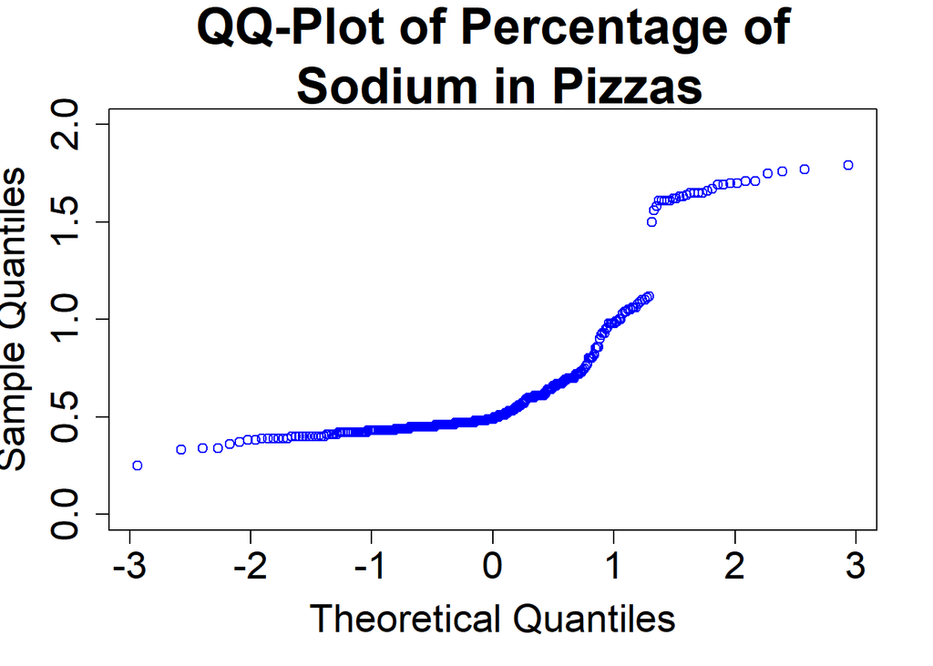

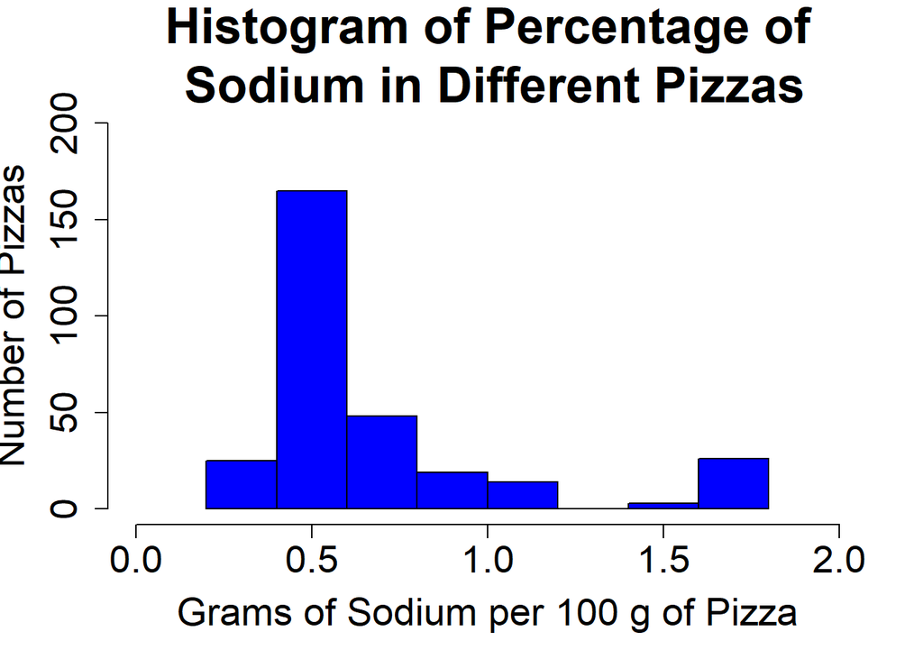

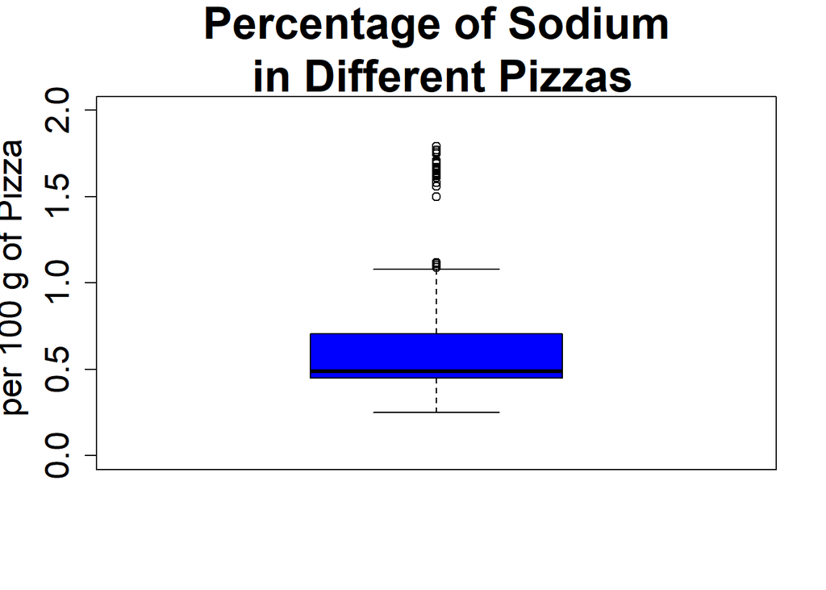

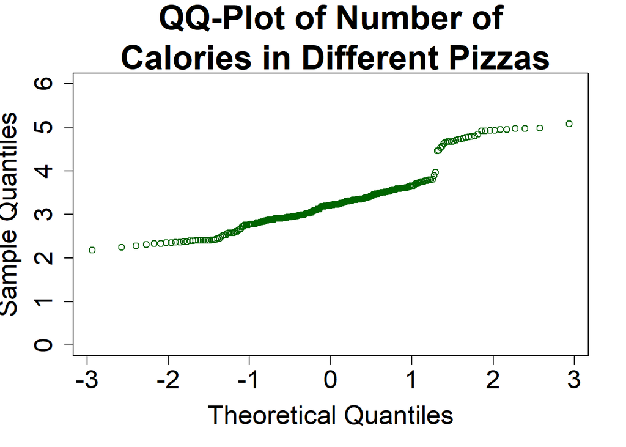

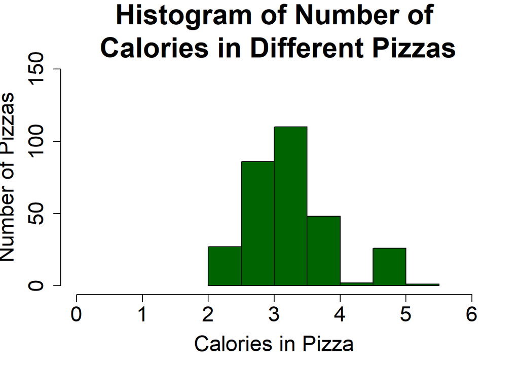

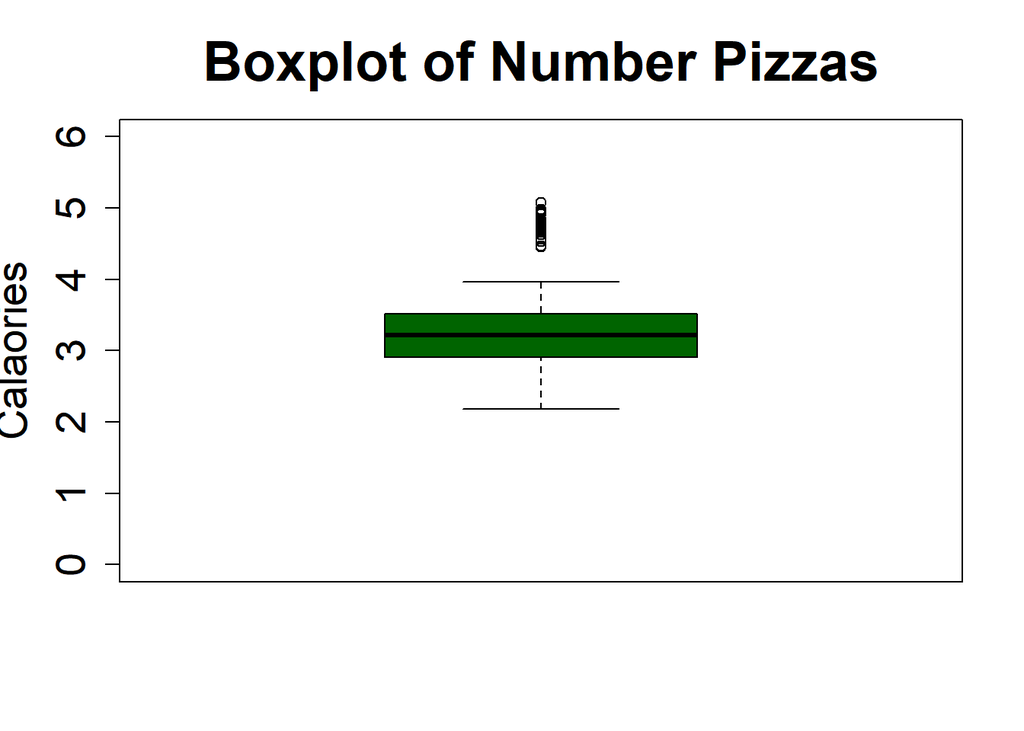

```r
qqnorm(pizza$sodium,
     main='QQ-Plot of Percentage of\n Sodium in Pizzas',
     cex.main=2.25,
     cex.axis=1.75,
     cex.lab=1.75,
     ylim=c(0,2),
     col='Blue')
hist(pizza$sodium,
     main='Histogram of Percentage of\n Sodium in Different Pizzas',
     xlab='Grams of Sodium per 100 g of Pizza',
     ylab='Number of Pizzas',
     cex.main=2.25,
     cex.axis=1.75,
     cex.lab=1.75,
     xlim =c(0, 2),
     ylim=c(0,200),
     col='Blue')
boxplot(pizza$sodium,
     main='Percentage of Sodium\n in Different Pizzas',
     cex.main=2.25,
     cex.axis=1.75,
     cex.lab=1.75,
     ylab='Grams of Sodium\n per 100 g of Pizza',
     ylim=c(0,2),
     col='Blue')

qqnorm(pizza$cal,
     main='QQ-Plot of Number of\n Calories in Different Pizzas',
     cex.main=2.25,
     cex.axis=1.75,
     cex.lab=1.75,
     ylim=c(0,6),
     col='Dark Green')
hist(pizza$cal,
     main='Histogram of Number of\n Calories in Different Pizzas',
     cex.main=2.25,
     cex.axis=1.75,
     cex.lab=1.75,
     xlab='Calories in Pizza',
     ylab='Number of Pizzas',
     xlim =c(0, 6),
     ylim=c(0,150),
     col='Dark Green')
boxplot(pizza$cal,
     main='Boxplot of Number Pizzas',
     cex.main=2.25,
     cex.axis=1.75,
     cex.lab=1.75,
     ylab='Calaories',
     ylim=c(0,6),
     col='Dark Green')
```

**Figure 1.** Q-Q Plots (left), Histograms (middle), and Boxplots (right) for the percentage of sodium (top row) and number of calories (bottom row) in different pizzas.

### Question 5

**Outliers**  
Use the `ezids::outlierKD2()` function to remove the outliers for sodium, then run the function again to remove outliers on calories. Re-do the QQ-plots for these two variables. Do you see much improvements?

**Answer:**  
Yes. Improvements are clearly seen in both Figures 2 and 3 below, when outliers are removed. The qq-plots show a better fit, the box plots show smaller width. The shape of this histogram doesn’t really change at all but it shows a slightly narrower distribution after the outliers are removed. What’s also interesting, and not what I expected, is that the number of counts in the pain part of the distribution decreases after the outliers are removed.

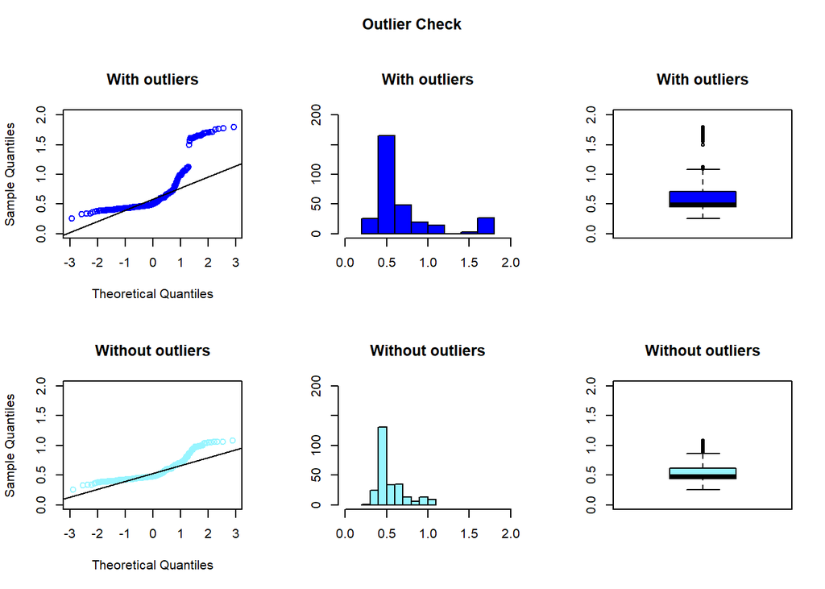

```r
outlierKD2(pizza, sodium, rm=FALSE, boxplt=TRUE, histogram=TRUE, qqplt=TRUE,
           with_col="Blue", without_col="cadetblue1",
           qqx=c(-3,3), qqy=c(0,2), histx=c(0,2), histy=c(0,200), boxy=c(0,2))
```

**Figure 2.** Comparing Q-Q Plots (left), Histograms (middle), and Boxplots (right) with outliers (top row) and without outliers (bottom row) for the percentage of sodium in different pizzas.

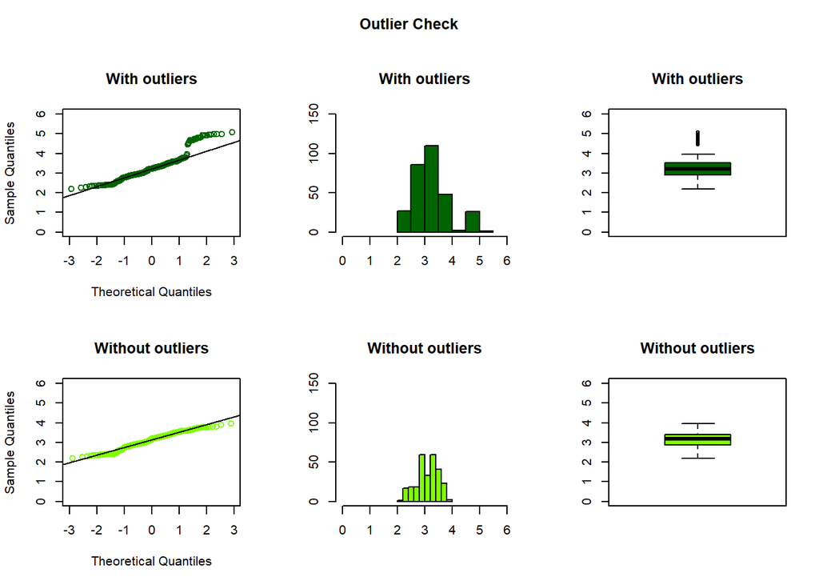

```r
outlierKD2(pizza, cal, rm=FALSE, boxplt=TRUE, histogram=TRUE, qqplt=TRUE,
           with_col="Dark Green", without_col = "chartreuse",
           qqx=c(-3,3), qqy=c(0,6), histx=c(0,6), histy=c(0,150), boxy=c(0,6))
```

**Figure 3.** Comparing Q-Q Plots (left), Histograms (middle), and Boxplots (right) with outliers (top row) and without outliers (bottom row) for the number of calories in different pizzas.